# Introdução à Ciência de Dados

Mestrado Profissional em Administração

Prof. Washington Santos da Silva

IFMG - Campus Formiga

3 de julho de 2025

## Diário de Bordo

**O que vimos até aqui?**

- Aula 1 ✅
  - Apresentação da Disciplina ✅
  - Introdução e Contextualização ✅
  - O que é Ciência de Dados? ✅
  - Pesquisa Reproduzível e Ciência de Dados ✅
  - Papéis Profissionais ✅
  - Aplicações ✅
  - Habilidades Interpessoais e Analíticas ✅
  - Apresentação da Disciplina ✅
  - Configurações: Git/GitHub ✅
- Aula 2 ✅
  - Metodologia CRISP-DM ✅
  - Tipos de Análise de Dados ✅
  - Introdução ao RStudio e criação do **seu** Projeto da Disciplina ✅
  - Introdução ao Sistema de Publicação Quarto ✅
  - Introdução ao Git e GitHub: controle de versão e criação do **seu** repositório no GitHub ✅
- Aula 3 ✅
  - Breve Revisão sobre o RStudio ✅
  - Sistema de Publicação Quarto: (Cont.) ✅
  - Introdução ao Git e GitHub: (Cont.) ✅
  - Sessão Prática: Fluxo de trabalho integrando RStudio/Quarto/R/Git/GitHub ✅
- Aula 4 ✅
  - Conceitos de Variáveis e Observações em Estatística ✅
  - Conceito de Dados Organizados (*Tidy Data*) ✅
  - Tipos atômicos e classes principais de dados da linguagem R ✅
  - Tipos de Dados Tradicionais em Finanças: ✅
    - Dados em Secção-Cruzada (ou Transversal) (*Cross-Section Data*) ✅
    - Dados em Secções-Cruzadas Combinadas (*Pooled Cross-Section Data*) ✅
    - Dados em Séries Temporais (*Time Series Data*) ✅
    - Dados em Painel (ou Longitudinais) (*Panel Data*) ✅
  - Importação e Preparação de Dados Típicos de Finanças com exemplos práticos ✅
- Aula 5 ✅
  - Metodologia CRISP-DM: Fases 2 e 3 ✅
  - Revisão sobre Dados Organizados (*Tidy Data*) ✅
  - Introdução ao Pacote tidyr: função pivot_longer() ✅
  - Introdução ao Pacote dplyr: funções select() e filter() ✅
  - Exercícios ✅
- Aula 6 ✅
  - Função mutate ✅
  - Funções group_by e summarize ✅
  - Exercícios ✅
- Aula 7 ✅
  - Introdução ao Pacote dplyr: Tipos Básicos de *joins* ✅
  - Exercícios ✅
- Aula 8 ✅
  - Modelos ✅
  - Conceitos Fundamentais de Probabilidade ✅
    - O que é Probabilidade? ✅
    - Probabilidade Condicional e Independência ✅
    - Amostra Aleatória ✅
    - Variáveis Aleatórias e Funções de Probabilidade ✅
    - Função de Distribuição Acumulada ✅
    - Lei dos Grandes Números ✅
  - Distribuições de Probabilidade de VA Discretas ✅
    - Distribuição de Bernoulli ✅
    - Características de uma Distribuição de Probabilidade ✅
      - Valor Esperado ✅
      - Variância e Desvio-Padrão ✅
      - Assimetria e Curtose ✅
  - Distribuição Binomial ✅
  - Distribuições de Probabilidade de VA Contínuas ✅
    - Teorema Central do Limite ✅
    - Distribuição Normal ✅
- Aula 10 ✅
  - Simulação de Monte Carlo - Aplicações ✅
  - Aplicação - Valor-em-Risco (VaR) ✅
    - Pacote tidyquant, Séries de Preços e de Rretornos de Acões ✅
    - Método Paramétrico ✅
    - Método Histórico ✅
    - Método de Simulação de Monte Carlo ✅
  - Aplicação - ES/CVaR ✅

## Nesta Aula

**Tópicos - Fundamentos de Estatística e Simulação**

- Revisão de Matemática
- Estatística, Probabilidade e Simulação
- Parâmetro, Estimador/Estatística, Estimativa
- Métodos de Inferência Estatística
- Estimação Pontual de Parâmetros Populacionais
  - Método da Máxima Verossimilhança
  - Propriedades de Estimadores

**Diretrizes para Aulas Mais Produtivas**

⌨️ **Código com método:**

95% dos erros são evitáveis com:

- Atenção na digitação
- Respeitar a sequência lógica de etapas
- Revisão antes de pedir ajuda

🤝 **Inteligência colaborativa:**

- Compartilhe conhecimento
- Resolva questões técnicas simples com colegas próximos
- Reserve ao professor as dúvidas conceituais complexas

💪 **Capacidade de Resolver Problemas**

Cada erro resolvido é uma evolução da sua habilidade analítica

# Funções Matemáticas em R

## Função Matemática

**Definição**

Uma função matemática é uma relação entre dois conjuntos, onde cada elemento do primeiro conjunto (chamado de domínio) está associado a exatamente um elemento do segundo conjunto (chamado de imagem).

Formalmente, uma função $f$ de um conjunto $X$ para um conjunto $Y$ é uma regra que atribui a cada elemento $x \in X$ um único elemento $y \in Y$, denotado por $f(x)$.

Podemos escrever:

$$f: X \to Y$$

onde $f(x)$ é o valor de $f$ em $x$.

## Criando Funções Matemáticas Simples em R

- Função Linear

$$f(x) = 2x + 1, \quad x \in \mathbb{R}$$

```r
# cria uma função linear
funcao_linear <- function(x) {
  return(2*x + 1)
}

# calculo de f(2)
funcao_linear(2)
```

```
[1] 5
```

## Função Quadrática

$$f(x) = -x^2 + x + 2, \quad x \in \mathbb{R}$$

```r
# cria uma função quadrática
funcao_quadratica <- function(x) {
  return(-x^2 + x + 2)
}

# calculo de f(2)
funcao_quadratica(2)
```

```
[1] 0
```

## Função Cúbica

$$f(x) = x^3 - 2x - 5, \quad x \in \mathbb{R}$$

```r
# cria uma função cúbica
funcao_cubica <- function(x) {
  return(x^3 - 2*x - 5)
}

# calculo de f(2)
funcao_cubica(2)
```

```
[1] -1
```

## Função Exponencial

$$f(x) = e^{3x}, \quad x \in \mathbb{R}$$

```r
# cria uma função exponencial
funcao_exponencial <- function(x) {
  return(exp(3*x))
}

# calculo de f(2)
funcao_exponencial(2)
```

```
[1] 403.43
```

## Função Logaritmo

$$f(x) = \ln(x), \quad x \in (0, \infty)$$

```r
# cria uma função logaritmo
funcao_logaritmo <- function(x) {
  return(log(x))
}

# calculo de f(2)
funcao_logaritmo(2)
```

```
[1] 0.69315
```

# Gráficos de Funções Matemáticas em R

## Função curve()

**Definição**

A função `curve()` de R permite que você crie gráficos de funções matemáticas de forma simples.

## Função Linear

**Gráfico: Função Linear**

$$f(x) = 2x + 1$$

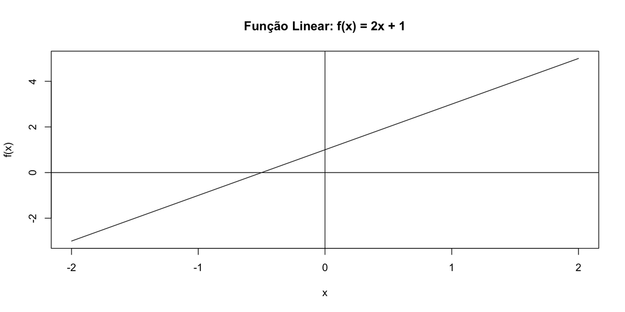

```r
curve(funcao_linear,
      from = -2,
      to = 2,
      ylab = "f(x)",
      main = "Função Linear: f(x) = 2x + 1"
      )
abline(h = 0)
abline(v = 0)
```

## Função Quadrática

**Gráfico: Função Quadrática**

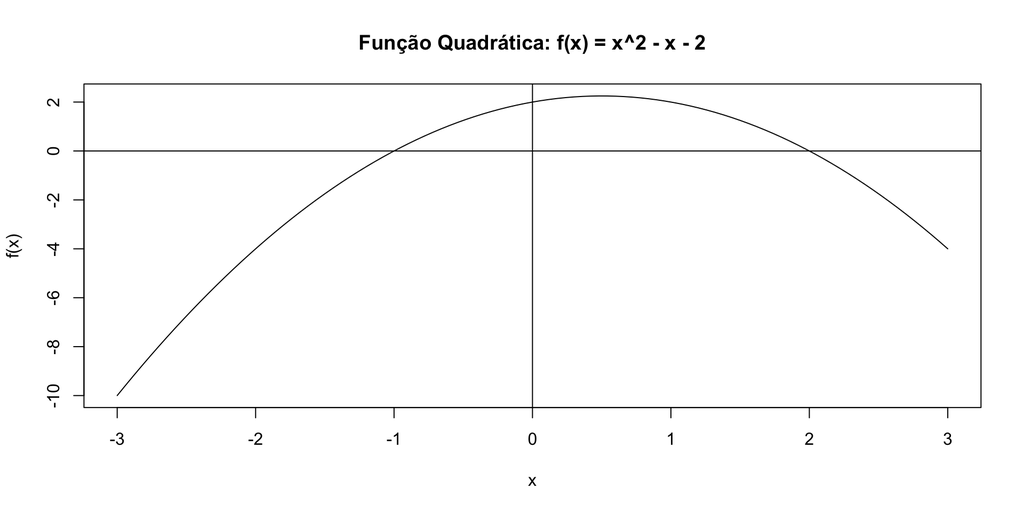

```r
curve(funcao_quadratica,
      from = -3,
      to = 3,
      ylab = "f(x)",
      main = "Função Quadrática: f(x) = x^2 - x - 2"
      )
abline(h = 0)
abline(v = 0)
```

## Função Cubica

**Gráfico: Função Cubica**

$$f(x) = x^3 - 2x - 5$$

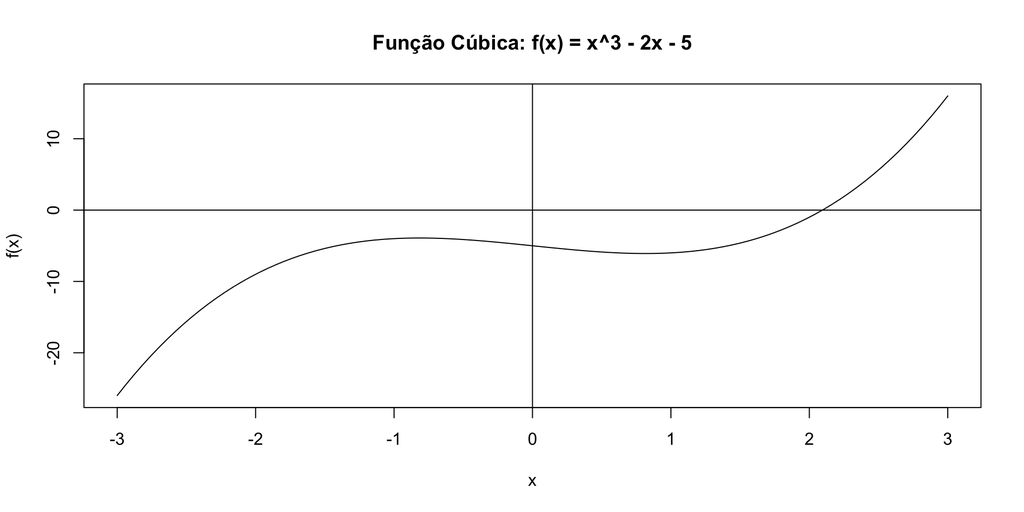

```r
curve(funcao_cubica,
      from = -3,
      to = 3,
      ylab = "f(x)",
      main = "Função Cúbica: f(x) = x^3 - 2x - 5"
      )
abline(h = 0)
abline(v = 0)
```

## Função Exponencial

**Gráfico: Função Exponencial**

$$f(x) = e^{3x}$$

[figure not shown]

```r
curve(funcao_exponencial,
      from = -1,
      to = 1,
      ylab = "f(x)",
      main = "Função Exponencial: f(x) = exp(x)"
     )
abline(h = 0)
abline(v = 0)
```

## Função Logaritmica

**Gráfico: Função Logaritmica**

$$f(x) = \ln(x) \quad (x > 0)$$

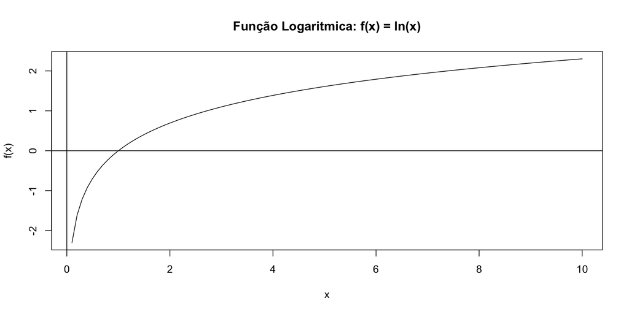

```r
curve(funcao_logaritmo,
      from = 0.1,
      to = 10,
      ylab = "f(x)",
      main = "Função Logaritmica: f(x) = ln(x)"
     )
abline(h = 0)
abline(v = 0)
```

# Raízes de Funções Matemáticas em R

## Raízes de uma Função

**Definição**

As raízes de uma função matemática são os valores de $x$ para os quais a função $f(x)$ é igual a zero. Formalmente, se $f$ é uma função de $x$, então os valores de $x$ que satisfazem a equação

$$f(x) = 0$$

são chamados de raízes da função $f$. Em outras palavras, as raízes são os pontos onde a curva da função intersepta o eixo $x$.

## Função uniroot de R Base

**Definição**

A função `uniroot` da base R encontra raízes de funções contínuas reais de uma variável, utilizando o **método da bisseção**.

- Raiz de uma Função Cúbica

```r
# Definindo a função cúbica
cubica <- function(x) {
  x^3 - 2*x - 5
}

# Encontrando uma raiz no intervalo [2, 3]
uniroot(cubica, interval = c(2, 3))
```

```
$root
[1] 2.0945

$f.root
[1] -0.0001147

$iter
[1] 5

$init.it
[1] NA

$estim.prec
[1] 0.000061035
```

## Função fzero do Pacote pracma

**Definição**

A função `fzero` do pacote pracma encontra as raízes de funções contínuas de funções de uma variável

- Raízes de uma Função Cúbica

```r
library(pracma)

# Definindo a função quadrática
fcubica <- function(x) {
  return(x^3 - 2*x - 5)
}

# Encontrando uma raiz no intervalo [-10, 10]
fzero(fcubica, c(2, 3))
```

```
$x
[1] 2.0946

$fval
[1] -0.00000000000000088818
```

## Diferença entre `fzero()` e `uniroot()`

**Comparação entre as funções**

| Função | Pacote | Método usado | Intervalo obrigatório? | Comentário |
| --- | --- | --- | --- | --- |
| `fzero()` | `pracma` | Método híbrido (Newton-Raphson, secante, etc.) | **Não** – pode iniciar com ponto único ou intervalo | Mais flexível, mas depende do pacote externo |
| `uniroot()` | Base R | Bisseção | **Sim** – exige intervalo com mudança de sinal $f(a) \cdot f(b) < 0$ | Mais robusto e confiável, mas menos flexível |

- `fzero()` aceita ponto inicial e escolhe o melhor método.
- `uniroot()` requer que você **garanta a mudança de sinal** no intervalo fornecido.

# Derivadas de Funções

## Derivada Primeira

**O que é a Derivada Primeira?**

A **derivada primeira** de uma função em um ponto é a **taxa de variação instantânea** da função nesse ponto.

#### Intuição 1: Taxa de Variação

Imagine que você está dirigindo um carro. Se $f(t)$ representa a **posição** do carro ao longo do tempo, então:

- A derivada $f'(t)$ representa a **velocidade instantânea** — ou seja, **quão rápido a posição está mudando** naquele exato instante.

Isso é como olhar no velocímetro do carro naquele segundo.

#### Intuição 2: Inclinação da Reta Tangente

Se você tem uma curva de uma função $f(x)$, a derivada $f'(x_0)$ representa a **inclinação da reta tangente** à curva no ponto $x_0$.

- Se $f'(x_0) > 0$: a curva está **subindo** nesse ponto.
- Se $f'(x_0) < 0$: a curva está **descendo** nesse ponto.
- Se $f'(x_0) = 0$: a curva tem uma **reta horizontal** naquele ponto (possível máximo ou mínimo).

#### Definição Formal

$$f'(x) = \lim_{h \to 0} \frac{f(x + h) - f(x)}{h}$$

Esse limite calcula a **inclinação da reta secante** entre dois pontos muito próximos.

Quando $h \to 0$, essa secante vira a **reta tangente** à curva no ponto.

## Função Polinomial

**Derivada de Função Polinomial**

A regra para calcular a derivada de uma função polinomial é dada por:

$$f(x) = a_n x^n + a_{n-1} x^{n-1} + \cdots + a_1 x + a_0$$

então a derivada $f'(x)$ é:

$$f'(x) = n a_n x^{n-1} + (n-1) a_{n-1} x^{n-2} + \cdots + 1 a_1$$

Dada a função:

$$f(x) = 3x^2$$

A derivada primeira de $f(x)$ é calculada da seguinte forma:

$$f'(x) = \frac{d}{dx}(3x^2)$$

Usando a regra da potência, temos:

$$f'(x) = 3 \cdot 2x^{2-1}$$

Simplificando, obtemos:

$$f'(x) = 6x$$

Portanto, a derivada primeira de $f(x) = 3x^2$ é:

$$f'(x) = 6x$$

## Pacote Deriv para Derivadas Simbólicas

```r
# ativa o pacote
library(Deriv)

# primeira derivada de uma função quadrática
primeira_derivada <- Deriv(~ 3*x^2, "x")
primeira_derivada
```

```
6 * x
```

## Pacote Deriv para Derivadas Simbólicas

- Encontrando a primeira derivada de $fx) = x^2 - 4*x + 4$

```r
# ativa o pacote
library(Deriv)

# primeira derivada de uma função quadrática
primeira_derivada <- Deriv(~ x^2 - 4 * x + 4, "x")
primeira_derivada
```

```
2 * x - 4
```

## $f(x) = -xˆ2$ - Primeiras Derivadas

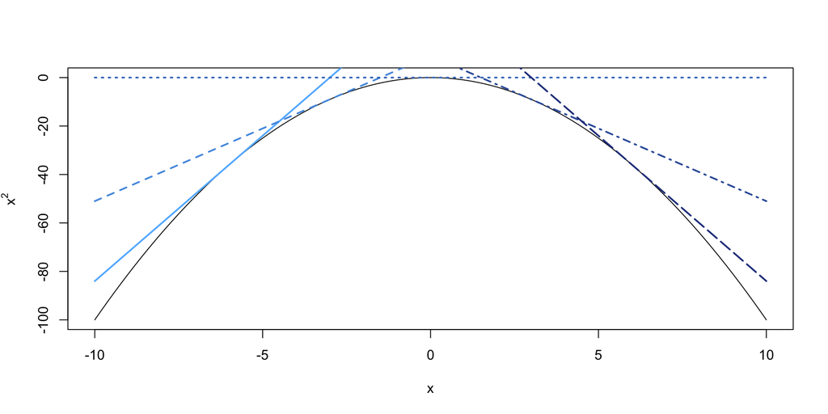

## Pacote numDeriv para Derivadas Numéricas

**Descrição**

Vimos que a primeira derivada de $f(x) = 3x^2$ é $f^{'}(x) = 6x$.

Qual o valor de $f^{'}(2)$?

$$f^{'}(2) = 6 \times 2 = 12$$

```r
# carrega o pacote
library(numDeriv)

# define a função quadrática
funcao <- function (x) {return(3*x^2)}

# Derivada numérica da função quadrática
primeira_derivada_numerica <- grad(funcao, x = 2)
primeira_derivada_numerica
```

```
[1] 12
```

## Derivada Segunda de Funções

**O que é a Derivada Segunda?**

A **derivada segunda** de uma função é a derivada da derivada primeira.

Se a derivada primeira mede a **velocidade de variação** da função, a derivada segunda mede a **aceleração** ou a **curvatura** — ou seja, **o quanto a taxa de variação está mudando**.

**Exemplo:**

Se $f(x) = 3x^2$, então:

1. Derivada primeira:

$$f'(x) = 6x$$

2. Derivada segunda:

$$f''(x) = \frac{d}{dx}(6x) = 6$$

Ou seja, a taxa de variação de $f(x)$ (a derivada primeira) cresce a uma taxa constante de 6.

## Derivada Segunda

**Regra Geral**

Se a função polinomial for:

$$f(x) = a_n x^n + a_{n-1} x^{n-1} + \cdots + a_1 x + a_0$$

A derivada primeira é:

$$f'(x) = n a_n x^{n-1} + (n-1)a_{n-1}x^{n-2} + \cdots + a_1$$

E a derivada **segunda** é:

$$f''(x) = n(n-1) a_n x^{n-2} + (n-1)(n-2) a_{n-1} x^{n-3} + \cdots$$

- Repare que **o grau da função cai duas vezes**, e os coeficientes são multiplicados por **dois fatores consecutivos decrescentes**.

Exemplo: Para $f(x) = 3x^2$, temos:

- $f'(x) = 6x$
- $f''(x) = 6$

## Derivada Segunda com o Pacote Deriv

```r
library(Deriv)

# define a função
f <- function(x) {3*x^2}

# primeira derivada
derivada_primeira <- Deriv(f)

# segunda derivada
derivada_segunda <- Deriv(derivada_primeira)
derivada_segunda
```

```
function (x)
6
```

## Derivada Segunda - Exemplo

```r
# define a função
f <- function(x) {x^2 - 4*x + 4}

# primeira derivada
derivada_primeira <- Deriv(f)

# segunda derivada
derivada_segunda <- Deriv(derivada_primeira)
derivada_segunda
```

```
function (x)
2
```

## Derivada Segunda com numDeriv

**Derivada Segunda Numérica**

Vamos calcular numericamente a derivada segunda de $f(x) = 3x^2$ no ponto $x = 2$.

Lembrando:

$$f''(x) = 6$$

```r
library(numDeriv)

# função original
f <- function(x) {3*x^2}

# derivada segunda usando função hessian
segunda_derivada_numerica <- hessian(f, x = 2)
segunda_derivada_numerica
```

```
     [,1]
[1,]    6
```

## Interpretação Geométrica da Derivada Segunda

**Nota**

A derivada segunda indica se a curva está:

- **Concava para cima** ($f''(x) > 0$): como um $\cup$
- **Concava para baixo** ($f''(x) < 0$): como um $\cap$
- **Reta (sem curvatura)** ($f''(x) = 0$)

**No caso de $f(x) = 3x^2$**, temos:

- Derivada segunda constante: $f''(x) = 6$
- Isso significa que a curva tem concavidade **para cima** constante, como um “U” aberto.

## Interpretação Geométrica da Derivada Segunda

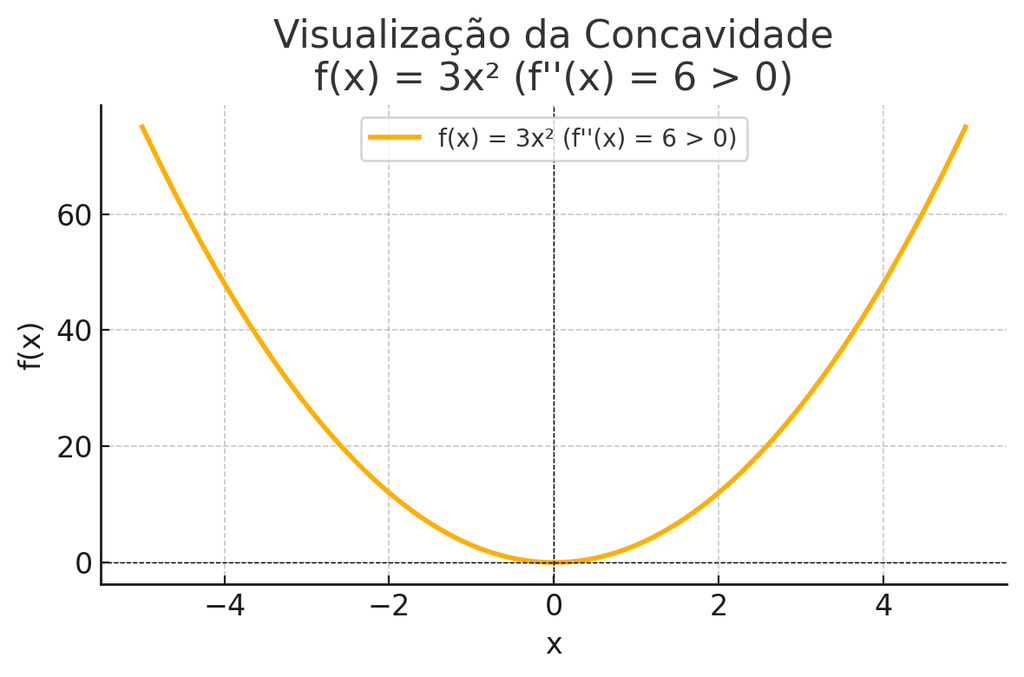

Função tem Mínimo

## Interpretação Geométrica da Derivada Segunda

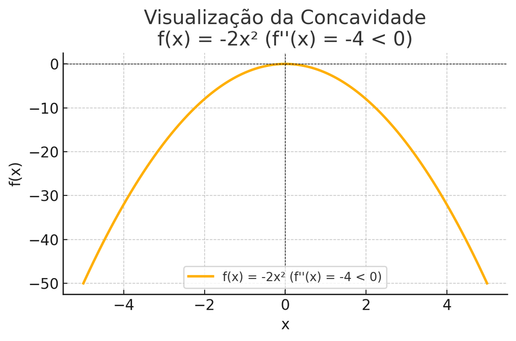

Função tem Máximo

## Interpretação Geométrica da Derivada Segunda

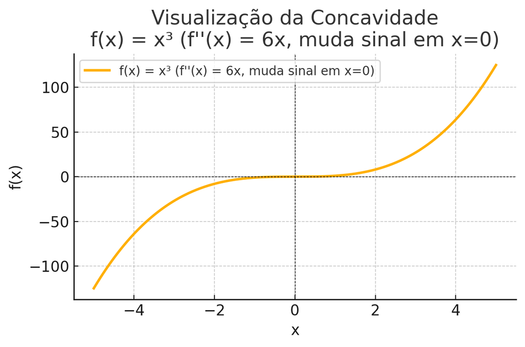

Ponto de Inflexão

## Interpretação Geométrica da Derivada Segunda

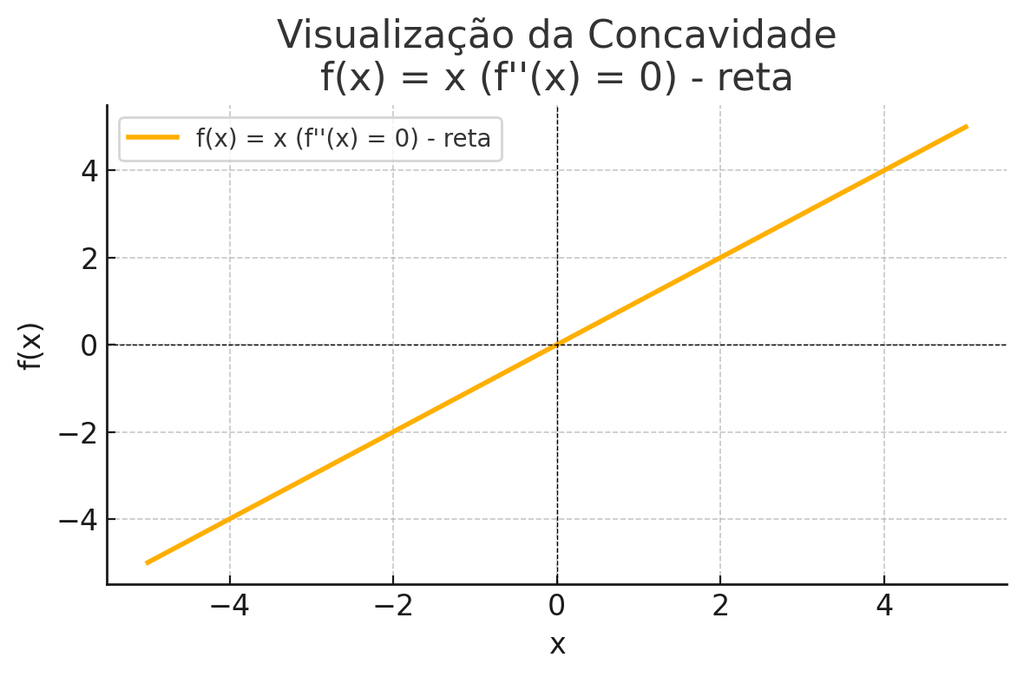

Função sem Concavidade/Curvatura

# Encontrando Máximos ou Mínimos de Funções

## Encontrando o Máximo (ou Mínimo) de uma Função

**Procedimento**

Para encontrar máximos ou mínimos de uma função, siga os passos:

1. Encontre a primeira derivada da função $f(x)$, denotada por $f'(x)$.
2. Resolva $f'(x) = 0$ para encontrar os **pontos críticos**.
3. Calcule a segunda derivada $f''(x)$.
4. Avalie $f''(x)$ em cada ponto crítico:
   - Se $f''(x) < 0$, há um **máximo local**.
   - Se $f''(x) > 0$, há um **mínimo local**.
   - Se $f''(x) = 0$, o teste é inconclusivo.

Quando $f'(x) = 0$ e $f''(x) < 0$, a função está no **topo de uma colina** — um máximo local.

## Maximizando uma Função

**Exemplo**

Considere $f(x) = -x^2 + x + 2$. Vamos aplicar o procedimento:

1. Primeira derivada:

$$f'(x) = \frac{d}{dx}(-x^2 + x + 2) = -2x + 1$$

2. Pontos críticos:

$$-2x + 1 = 0 \Rightarrow x = \frac{1}{2}$$

3. Segunda derivada:

$$f''(x) = \frac{d^2}{dx^2}(-x^2 + x + 2) = -2$$

4. Como $f''\left(\frac{1}{2}\right) = -2 < 0$, temos um **máximo local**.
5. Valor máximo:

$$f\left(\frac{1}{2}\right) = -\frac{1}{4} + \frac{1}{2} + 2 = \frac{9}{4}$$

- Resultado: máximo local em $x = \frac{1}{2}$, sendo o valor da função neste ponto $f(1/2) = \frac{9}{4}$

## Gráfico: $f(x) = -x^2 + x + 2$

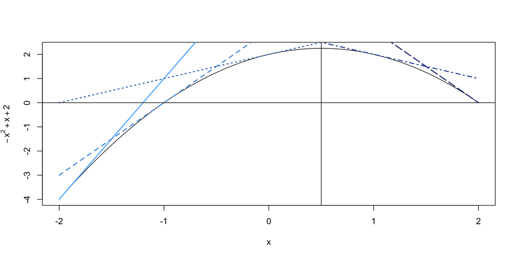

## Função `optimize()` em R

**Como encontrar o **máximo** de uma função?**

A função `optimize()` do R é projetada para **minimizar** funções reais de uma variável. Para **maximizar** uma função $f(x)$, usamos a equivalência:

$$\max f(x) = \min [-f(x)]$$

Ou seja, maximizamos $f(x)$ **minimizando $-f(x)$**.

Vamos aplicar isso à função:

$$f(x) = -x^2 + x + 2$$

```r
# Define a função original
f <- function(x) {-x^2 + x + 2}

# Maximização via minimização de -f(x)
resultado <- optimize(function(x) -f(x), interval = c(-1, 2))

# Recupera os resultados
x_max <- resultado$minimum            # ponto de máximo
f_max <- -resultado$objective         # (-1)xf(x_max)

# Exibe os resultados
list(x_max = x_max, f_max = f_max)
```

```
$x_max
[1] 0.5

$f_max
[1] 2.25
```

**Resumo**:

- `optimize()` encontra o ponto que **minimiza** a função fornecida.
- Para obter um **máximo**, forneça $-f(x)$ e depois **inverta o sinal** do resultado para $f(x)$

**Resultado final**:

- A função $f(x) = -x^2 + x + 2$ atinge seu **máximo** em $x = 0,5$.
- O valor da função no ponto de máximo é:

$$f(0{,}5) = 2,25$$

## Encontrando Máximos com `optimize()` em R

**Por que multiplicar por -1?**

A função `optimize()` do R **minimiza** funções por padrão.

- Se queremos **maximizar** uma função $f(x)$, precisamos **transformar o problema**:

$$\max f(x) \;\equiv\; \min [-f(x)]$$

- Assim, usamos:

```r
optimize(function(x) -f(x), interval = c(a, b))
```

**Resumo**: Maximizar $f(x)$ é o mesmo que minimizar $-f(x)$.

## Exemplo

**Maximização de Função com `optimize()`**

Vamos encontrar o **máximo** da função:

$$f(x) = -x^2 + x + 2$$

no intervalo $[-1,; 2]$.

Como `optimize()` **minimiza** funções, usamos:

```r
resultado <- optimize(function(x) -f(x), interval = c(-1, 2))
```

Ou seja, minimizamos $-f(x)$ para **encontrar o máximo de $f(x)$**.

## Visualização: Maximizar $f(x)$ = Minimizar $-f(x)$

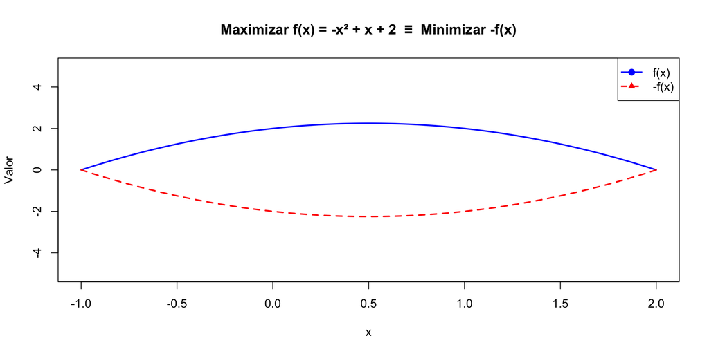

## Interpretação

**Visualização**

- A **curva azul** representa $f(x)$ (a função que queremos maximizar).
- A **curva vermelha** representa $-f(x)$.
- O `optimize()` encontra o **mínimo da curva vermelha**, que ocorre **no mesmo ponto** em que a curva azul atinge o **máximo**.
- Portanto, maximizar $f(x)$ é equivalente a minimizar $-f(x)$.

## Exercícios

**Exercício 1**

Utilizando a criação de funções matemáticas e a função `curve`, crie os gráficos das seguintes funcões:

1. A função de demanda linear é definida como: $f(x) = 50 - 2x$ onde $x$ é a quantidade demandada e $f(x)$ é o preço.
2. A função de utilidade Cobb-Douglas é definida como: $f(x) = 10x^{0.5}$, onde $x$ é a quantidade de um bem e $f(x)$ é a utilidade.
3. A função de crescimento logístico é definida como: $f(x) = \frac{100}{1 + e^{-0.1(x - 50)}}$ onde $x$ é o tempo.

## Exercícios

**Exercício 2**

Utilizando a função `optimize` da linguagem R. Encontre o valor de $x$ que maximiza a seguinte função quadrática:

$$f(x) = -2x^2 + 4x + 1$$

# Fundamentos de Probabilidade, Estatística e Simulação

## Recaptulando: Teoria da Probabilidade

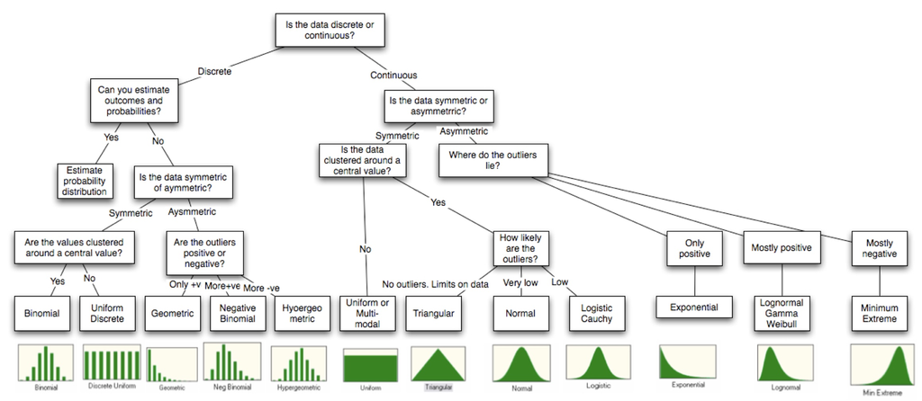

Modelos Probabilísticos = Distribuições de Probabilidade

## Recaptulando: Teoria da Probabilidade

**Característica da Distribuição de Probabilidade de uma VA:**

#### **Valor Esperado ou Média** = $E(Y)$

Média ponderada de todos os valores possíveis que $Y$ pode assumir, ponderada pelas suas respectivas probabilidades:

$$E[Y] = \sum_{y} y \cdot P(Y = y) \quad \text{(variáveis discretas)}$$
$$E[Y] = \int_{-\infty}^{\infty} y \cdot f(y) \, dy \quad \text{(variáveis contínuas)}$$

#### **Variância** = $V(Y)$ = $\sigma^2$

A variância de uma variável aleatória mede a variabilidade dos valores de $Y$ em torno do seu valor esperado.

$$\text{Var}(Y) = E[(Y - E[Y])^2] = E[Y^2] - (E[Y])^2$$

#### **Desvio-Padrão** = $\sqrt{V(Y)}$ = $\sigma$

O desvio-padrão é a raiz quadrada da variância, fornecendo uma medida de variabilidade que está na mesma unidade de Y.

$$\sqrt{\text{Var}(X)} = \sigma$$

#### **Quantis**

Os quantis são valores que particionam a distribuição de modo que há uma probabilidade específica de que a variável aleatória seja menor que o quantil. Por exemplo, o quantil de 0.25 (ou o primeiro quartil) é o valor abaixo do qual 25% dos dados podem ser encontrados.

#### **Coeficiente de Assimetria**

Mede a assimetria de uma distribuição. Uma distribuição perfeitamente simétrica, como a distribuição normal, possui coeficeinte de assimetria igual a zero.

$$\text{Assimetria} = E\left[\left(\frac{Y - E[Y]}{\sigma_Y}\right)^3\right]$$

#### **Coeficiente de Curtose**

$$\text{Curtose} = E\left[\left(\frac{Y - E[Y]}{\sigma_Y}\right)^4\right] - 3$$

## Recaptulando: Teoria da Probabilidade

**Distribuição de Diversas Variáveis Aleatórias**

#### **Distribuição Conjunta**: $f_{X,Y}(x,y)$

A distribuição **conjunta** de duas variáveis aleatórias X e Y é a função de densidade de probabilidade que descreve a probabilidade de X e Y assumirem valores específicos simultaneamente.

- **Discreta**: $f(x, y) = P(X = x \cap Y = y)$
- **Contínua**: $f(x, y)$ é uma densidade tal que
  $$\iint f(x, y)\,dx\,dy = 1$$

#### **Distribuição Marginal**: $f_X(x)$ e $f_Y(y)$

As distribuições **marginais** mostram o comportamento de **uma única variável**.

São obtidas a partir da distribuição conjunta somando (ou integrando) sobre a outra variável:

- Para $X$:

  $$f_1(x) = \sum_y f(x, y) \quad \text{ou} \quad f_1(x) = \int f(x, y)\,dy$$

#### **Distribuição Condicional**: $f_{X|Y}(x|y)$

A **distribuição condicional** de $Y$ dado $X = x$ é:

$$f(y \mid x) = \frac{f(x, y)}{f_1(x)} \quad \text{(se } f_1(x) > 0\text{)}$$

#### Independência de Variáveis Aleatórias

$X$ e $Y$ são **independentes** se:

$$f(x, y) = f_1(x) \cdot f_2(y)$$

#### **Covariância**: $Cov(X, Y)$

A covariância entre duas variáveis aleatórias X e Y é uma medida da direção da relação linear entre elas.

$$\text{Cov}(X, Y) = E[(X - \mu_X)(Y - \mu_Y)] = E(XY) - E(X)E(Y)$$

#### **Correlação**: $\rho_{X, Y}$

A correlação é a covariância normalizada pelos desvios-padrão de X e Y, fornece uma medida da relação linear entre as variáveis que varia entre -1 e +1.

$$\text{Cor}(X, Y) =
E\left[ \left( \frac{X - \mu_X}{\sigma_X} \right)\left( \frac{Y - \mu_Y}{\sigma_Y} \right) \right] = \frac{\text{Cov}(X, Y)}{\sigma_X \sigma_Y}$$

## Simulação (Método) de Monte Carlo

**Aplicações**

Simulação é usada para:

1. Entender o Processo Gerador dos Dados assumido ✅
2. Resolver problemas envolvendo probabilidades (i.e., estimar probabilidades) ✅
3. Calcular características de funções densidade de probabilidade ✅
4. Transformar resultados estatísticos em quantidades de interesse ✅
5. Obter uma resposta correta: mais fácil que cálculos matemáticos ✅
6. Avaliar **estimadores** de **parâmetros** (hoje)

## Como Aprender o Processo Gerador a partir dos Dados?

**Processo Gerador dos Dados**

- Teoria da Probabilidade: **Assume o Processo Gerador dos Dados** ✅
- Inferência Estatística: **Aprende o Processo Gerador dos Dados** a partir dos dados disponíveis

## Como aprender o Processo Gerador a partir dos Dados?

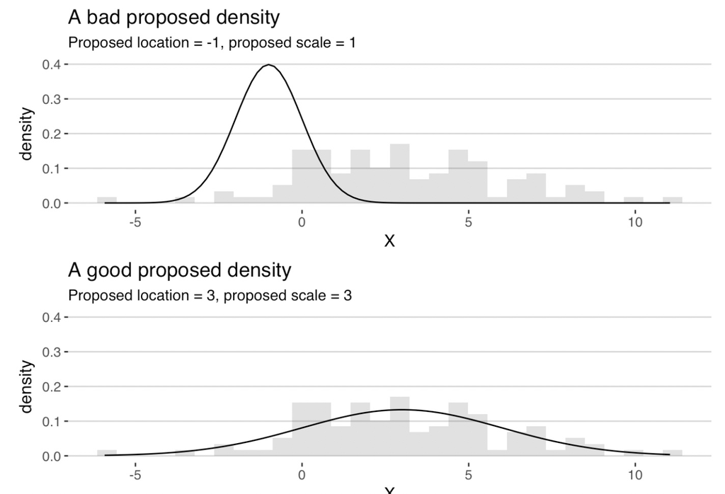

## Como Aprender o Processo Gerador a partir dos Dados?

**Processo Gerador dos Dados**

- Mais especificamente, qual membro da classe de distribuições de probabilidade assumida deu origem aos dados?
- O que precisamos conhecer de uma Distribuição Normal para calcular probabilidades?
  - Os parâmetros da distribuição.
  - $E(Y) = \mu$ e $V(Y) = \sigma^2$ (ou $\sqrt{\sigma^2} = \sigma$)

## Análise Estatística Tradicional

**Descrição**

- Assume que os dados são gerados por um modelo probabilístico conhecido (PGD), expresso como uma função matemática com parâmetros desconhecidos (i.e., distribuição de probababilidade).
- **Objetivo**: **Estimar** os **parâmetros** do modelo a partir dos **dados** disponíveis.
- **Métodos Típicos**:
  - Modelos de Regressão linear
  - Modelos de Regressão Não Linear (probit, logit, etc.)
  - Modelos para Séries Temporais (ARIMA, GARCH, VAR, etc.)
  - Modelos de Regressão para Dados em Painel (Efeitos Fixos, Efeitos Aleatórios, etc.)
- **Foco**: Inferência sobre os parâmetros para entender o processo subjacente.

## Questões de Interesse e Estatística Tradicional

**Exemplos de Questões de Interesse em Finanças**

- Quais são os fatores fundamentais que determinam os preços dos ativos e como esses fatores podem ser modelados para avaliar adequadamente o valor de um ativo?
- Como os retornos dos ativos financeiros, como ações ou títulos, são afetados por fatores macroeconômicos, mudanças na política monetária, ou eventos de mercado?
- Como estimar e prever a volatilidade dos mercados financeiros ou de ativos específicos?
- Os preços dos ativos refletem todas as informações disponíveis e, portanto, os mercados são informacionalmente “eficientes”?

# Parâmetro, Estimador, Estatística e Estimativa

## Notação e Conceitos

**Descrição**

|  | População | Amostra |
| --- | --- | --- |
| Símbolos | $\mu$, $\sigma$, $p$, $\rho$ | $\bar{x}$, $s$, $\hat{p}$, $r$ |
| Fixo ou aleatório? | Fixo (desconhecido) | Aleatório |
| Obtido por | Censo/dados históricos | Amostragem |
| Objetivo | Verdade a descobrir | Instrumento de inferência |

## Estimador Pontual (Fórmula)

**Descrição**

| Estimador | Fórmula | O que faz |
| --- | --- | --- |
| Média amostral | $\bar{X} = \frac{\sum_{i=1}^{n} X_i}{n}$ | Estima $\mu$ |
| Desvio amostral | $s = \sqrt{\frac{\sum_{i=1}^{n} (X_i - \bar{X})^2}{n-1}}$ | Estima $\sigma$ |
| Proporção amostral | $\hat{p} = \frac{X}{n}$ | Estima $p$ |
| Correlação amostral | $r = \frac{\sum (X_i - \bar{X})(Y_i - \bar{Y})}{(n-1)S_X S_Y}$ | Estima $\rho$ |

## Conceitos Centrais

**Estimador, Estatística e Estimativa**

- **Estimador**: Fórmula que aplicamos aos dados da amostra para obter um valor que estima uma parâmetro populacional.
- **Estatística**: É qualquer função dos dados da amostra. Todo estimador é uma estatística, mas nem toda estatística é um **bom** estimador.
- **Estimativas**: Resultados numéricos obtidos ao aplicar os estimadores

## Distinção Fundamental

### Estatística e Estimador

- São **variáveis aleatórias**
- **Natureza**: Função dos dados
- **Varia**: Entre amostras
- **Exemplo**: $\bar{X} = \frac{\sum X_i}{n}$
- **Distribuição**: Tem sua própria distribuição (**distribuição amostral**)

### Estimativa

- **É**: Um **número fixo**
- **Natureza**: Valor calculado
- **Fixo**: Para uma amostra específica
- **Exemplo**: $\bar{x} = 7.82$
- **Interpretação**: Realização de um estimador ou estatística

## Quiz

**Identifique: Parâmetro, Estimador/Estatística ou Estimativa?**

Uma empresa de e-commerce analisa seus pedidos:

1. A fórmula $s^2 = \frac{\sum_{i=1}^{n}(X_i - \bar{X})^2}{n-1}$ para calcular variância
2. O valor R$ 127,50 calculado como média de 1.000 pedidos
3. A verdadeira proporção de clientes satisfeitos (nota $\geq$ 8)
4. $\hat{p} = \frac{\sum_{i=1}^{n} Xi}{n}$ = proporção amostral de clientes satisfeitos
5. O desvio-padrão ($\sigma$) = R$ 45,00 de todos os pedidos históricos

## Quiz

**Respostas**

1. **Estimador/Estatística** (fórmula/método para estimar $\sigma^2$)
2. **Estimativa** (valor numérico específico de $\bar{X}$)
3. **Parâmetro** ($p$ - proporção populacional)
4. **Estimador/Estatística** (variável aleatória)
5. **Parâmetro** ($\sigma$ - desvio padrão populacional)

# Métodos de Inferência Estatística

## Inferência Estatística

**Definição**

#### **Inferência Estatística**:

Permite inferir características da população a partir da amostra, como médias, variâncias, proporções, etc.

#### **Objetivo**:

Estimar parâmetros populacionais, testar hipóteses e fazer previsões sobre a população com base em dados amostrais.

#### **Por que é necessária?**:

Na maioria das vezes, não é possível coletar dados de toda a população, então usamos amostras para fazer inferências sobre a população como um todo.

## Métodos de Inferência Estatística

**Tipos**

Os métodos clássicos de Inferência Estatística podem ser divididos em:

#### Métodos de **Estimação de Parâmetros**:

- Estimação **Pontual**: Procura fornecer o melhor valor único para um parâmetro desconhecido.
- Estimação **Intervalar**: Fornece um intervalo de valores que, com uma certa confiança, inclui o valor do parâmetro desconhecido.

#### **Testes de Hipóteses**:

Procedimentos para testar se uma afirmação sobre uma característica da população é verdadeira.

- Hoje, trataremos do Métodos de Estimação **Pontual** de parâmetros.

## Métodos Paramétricos

**Definição**

- Os métodos estatísticos **paramétricos** são um conjunto de técnicas de análise estatística que **assumem que os dados** amostrais vêm de uma população que pode ser **adequadamente descrita por uma distribuição de probabilidade** que é completamente especificada por um conjunto finito de parâmetros.
- Esses métodos são fundamentados na hipótese de que a **forma funcional da distribuição** subjacente aos dados pode ser conhecida, e o objetivo principal é estimar os valores dos parâmetros dessa distribuição.

## Métodos Paramétricos

**Características**

#### **Modelagem Baseada em Distribuição Conhecida**:

Utilizam modelos probabílisticos (dist. de probabilidade) que especificam uma forma funcional exata para a distribuição dos dados, como as distribuições normal, log-normal, binomial, Poisson, entre muitas outras.

#### **Estimação de Parâmetros**:

Envolve a determinação dos valores dos parâmetros da distribuição que melhor se ajustam aos dados observados, geralmente através de métodos como o de máxima verossimilhança, método dos momentos, bayesiano.

Há estimadores **pontuais** e **intervalares** para os parâmetros.

#### **Eficiência com Suposições Corretas**:

Quando as hipóteses do modelo estão corretas, os métodos paramétricos são geralmente mais eficientes (ou seja, têm menor variância) do que os métodos não paramétricos, proporcionando estimativas mais precisas e testes estatísticos mais poderosos.

#### **Modelos Interpretáveis**:

Os modelos e estimativas dos parâmetros são interpretáveis e, muitas vezes, fundamentados em teorias da área de aplicação.

# Métodos de Estimação Pontual de Parâmetros

## Estimação Pontual

**Estimação Pontual**

- Em Estatística, a **Estimação Pontual** envolve o uso de dados amostrais para estimar um parâmetro “populacional”.
- Um **Estimador** é uma função matemática dos dados da amostra.
- **Estimadores pontuais** são construídos para estimar parâmetros populacionais.
- Uma **Estimativa** é um valor específico de um estimador obtido com dados de uma amostra.

## Métodos de Estimação Pontual de Parâmetros

**Estimação Pontual**

- $\bar{x} = \frac{\sum{x_i}}{n}$ é um **estimador** de $E(Y) = \mu$.
- $\bar{x} = 3.14$ é uma **estimativa** de $E(Y) = \mu$.
- - É possível obter diversos estimadores para um parâmetro populacional, assim, o trabalho do estatístico é construir **bons estimadores**.

## Métodos de Estimação

**Alguns dos Principais Métodos**

- **Método da Máxima Verossimilhança**
- Método Bayesiano
- Método dos Momentos
- Método dos Momentos Generalizados
- …

## Método da Máxima Verossimilhança

**Definição**

- O [Método da Máxima Verossimilhança](https://en.wikipedia.org/wiki/Maximum_likelihood_estimation) (*MLE*, do inglês *Maximum Likelihood Estimation*) é um método amplamente utilizado em estatística para a estimação de parâmetros de modelos probabilísticos.
- Este método baseia-se no princípio de determinar os valores dos parâmetros que maximizam a função de verossimilhança, que representa a probabilidade de observar os dados amostrais dados os parâmetros do modelo.

## Método da Máxima Verossimilhança

**Função de Verossimilhança**

Considerando amostra $(X_1, X_2, \dots, X_n)$ de dados independentes e identicamente distribuídos de uma distribuição com vetor de parâmetros $\theta$, a função de verossimilhança $\mathcal{L}(\theta)$ é definida como:

$$L(\theta) = \prod_{i=1}^n f(x_i \mid \theta)$$
sendo $f(x_i \mid \theta)$ função de probabilidade de $x_i$ condicionada a $\theta$.

**Função de Log-Verossimilhança**

A função log-verossimilhança, denotada por $\ell(\theta)$, é utilizada para simplificar a otimização, sendo expressa por:

$$\ell(\theta|y) = \log L(\theta|y) = \sum_{i=1}^n \log f(x_i \mid \theta)$$

## Método da Máxima Verossimilhança

**Um problmea de Otimização**

Os parâmetros são estimados maximizando a função de log-verossimilhança ($\ell(\theta)$), envolvendo a resolução das equações:

$$\frac{\partial \ell(\theta|y)}{\partial \theta_j} = 0 \quad \text{para todo } j$$

A solução dessas equações fornece os estimadores de máxima verossimilhança $\hat{\theta}$.

## Como Encontrar o Máximo?

**Um problmea de Otimização**

**Objetivo**: Encontrar os valores de $\theta = \{\theta_1,...\theta_k\}$ que maximizam $\ell(\theta)$

**Analíticamente**: Ás vezes é possível.

- Tome a derivada parcial de $\ell(\theta)$ em relação à $\theta$.
- Iguale a derivada parcial a zero:

$$\Biggl|\frac{\partial \ell(\theta|y)}{\partial \theta_j}\Biggr| = 0$$
- Se possível, resolva para $\theta$ e chame de $\hat{\theta}$

- Verifique as condiçòes de **segunda ordem** para um máximo: a derivada parcial de segunda ordem em relação à $\theta$ é negativa?

**Numericamente**: Maioria das vezes.

Deixe o computador fazer o trabalho usando um método de otimização numérico.

## Função de (log-)Verossimilhança

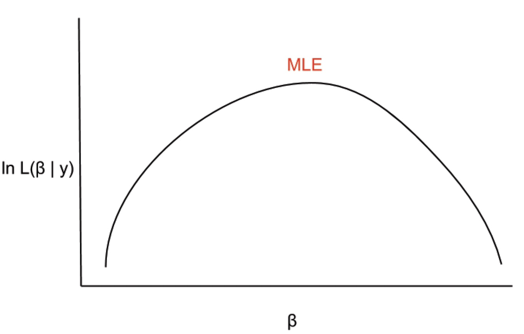

**Função de (log-)Verossimilhança**

Esta curva resume todas as informações que os dados fornecem sobre o vetor de parâmetros $\theta$, assumindo o modelo.

## Método da Máxima Verossimilhança

**EMV dos Parâmetros de uma Distribuição Normal**

Seja $X \sim N(\mu,\sigma^2)$, a função densidade de probabilidade (fdp) é:

$$f(x)={\frac {1}{{\sqrt {2\pi \sigma ^{2}}}\ }}\exp \left(-{\frac {(x-\mu )^{2}}{2\sigma ^{2}}}\right)$$

A correspondente fpd Para uma amostra i.i.d (indepentente e identicamente distribuída) é dada por:

$$f(x_{1},\ldots ,x_{n})=\prod _{i=1}^{n}f(x_{i})=\left({\frac {1}{2\pi \sigma ^{2}}}\right)^{n/2}\exp \left(-{\frac {\sum _{i=1}^{n}(x_{i}-\mu )^{2}}{2\sigma ^{2}}}\right)$$

Esta **classe** de distribuições tem dois parâmetros: $\theta = (\mu, \sigma)$; então maximizamos a função de verossimilhança $L(\mu ,\sigma) = f(x_1,\ldots,x_n ∣\mu,\sigma)$ em relação aos dois parâmetros simultaneamente ou, se possível, individualmente.

## Método da Máxima Verossimilhança

**EMV dos Parâmetros de uma Distribuição Normal**

Seja $X_1, X_2, \dots, X_n \overset{\text{iid}}{\sim} \mathcal{N}(\mu, \sigma^2)$. A função de **verossimilhança conjunta** é:

$$L(\mu, \sigma^2) = \prod_{i=1}^{n} \frac{1}{\sqrt{2\pi \sigma^2}} \exp\left( -\frac{(x_i - \mu)^2}{2\sigma^2} \right)$$

A **log-verossimilhança** é dada por:

$$\log L(\mu, \sigma^2) = -\frac{n}{2} \log(2\pi \sigma^2) - \frac{1}{2\sigma^2} \sum_{i=1}^n (x_i - \mu)^2$$

Para obter o estimador de máxima verossimilhança de $\mu$, mantemos $\sigma^2$ fixo e derivamos:

$$\begin{aligned}
\frac{\partial}{\partial \mu} \log L(\mu, \sigma^2)
&= \frac{\partial}{\partial \mu} \left[ -\frac{1}{2\sigma^2} \sum_{i=1}^n (x_i - \mu)^2 \right] \\
&= -\frac{1}{2\sigma^2} \cdot \sum_{i=1}^n \frac{\partial}{\partial \mu} (x_i - \mu)^2 \\
&= -\frac{1}{2\sigma^2} \cdot \sum_{i=1}^n [-2(x_i - \mu)] \\
&= \frac{1}{\sigma^2} \sum_{i=1}^n (x_i - \mu)
\end{aligned}$$

Igualando a zero e resolvendo:

$$\frac{1}{\sigma^2} \sum_{i=1}^n (x_i - \mu) = 0
\;\Rightarrow\;
\sum_{i=1}^n (x_i - \mu) = 0
\;\Rightarrow\;
n\bar{x} - n\mu = 0
\;\Rightarrow\;
\boxed{\widehat{\mu} = \bar{x} = \frac{1}{n} \sum_{i=1}^n x_i}$$

Esse estimador é **não-viesado**:

$$E(\widehat{\mu}) = E(\bar{x}) = \mu$$

e sua variância e desvio-padrão são:

$$\mathrm{Var}(\bar{x}) = \frac{\sigma^2}{n}, \quad \mathrm{DP}(\bar{x}) = \frac{\sigma}{\sqrt{n}}$$

Para encontrar o EMV de $\sigma^2$, derivamos a log-verossimilhança em relação a $\sigma^2$, mantendo $\mu = \bar{x}$:

$$\begin{aligned}
\frac{\partial}{\partial \sigma^2} \log L(\mu, \sigma^2)
&= -\frac{n}{2} \cdot \frac{1}{\sigma^2} + \frac{1}{2\sigma^4} \sum_{i=1}^n (x_i - \mu)^2 \\
&= -\frac{n}{2\sigma^2} + \frac{1}{2\sigma^4} \sum_{i=1}^n (x_i - \bar{x})^2
\end{aligned}$$

Igualando a zero:

$$-\frac{n}{2\sigma^2} + \frac{1}{2\sigma^4} \sum_{i=1}^n (x_i - \bar{x})^2 = 0$$

Multiplicando ambos os lados por $2\sigma^4$:

$$-n\sigma^2 + \sum_{i=1}^n (x_i - \bar{x})^2 = 0
\;\Rightarrow\;
\boxed{\widehat{\sigma}^2 = \frac{1}{n} \sum_{i=1}^n (x_i - \bar{x})^2}$$

Mas por que **não usamos** esse estimador?

Porque o estimador de máxima verossimilhança é **viesado**, especialmente para amostras pequenas. Por isso, usamos como estimador **não-viesado da variância populacional**:

$$\boxed{s^2 = \frac{1}{n-1} \sum_{i=1}^n (x_i - \bar{x})^2}$$

Esse divisor $n-1$ corrige o viés, pois reflete o fato de que $\bar{x}$ é uma estimativa empírica usada no cálculo da variância.

# Propriedades de Estimadores Pontuais

## Propriedades de Estimadores

**Estimador Não Viesado**

Um estimador $\hat{\theta}$ é dito não viesado para um parâmetro $\theta$ se o valor esperado do estimador é igual ao valor verdadeiro do parâmetro. Matematicamente:

$$\mathbb{E}(\hat{\theta}) = \theta$$

## Propriedades dos Estimadores de MV de $\mu$ e $\sigma$

**Propriedades do Valor Esperado de Variáveis Aleatórias**

#### Linearidade:

$$\begin{align}
E[X_1 + X_2 + \ldots + X_n ] &= E[X_1] + E[X_2] + \ldots + E[X_N] \\
E\left[\sum_{i=1}^n X_i\right] &= \sum_{i=1}^n E[X_i]
\end{align}$$

#### Valor Esperado de uma Constante:

$$E[c] = c \rightarrow E[cX] = cE[X]$$

#### Valor Esperado do Produto de Variáveis Independentes

$$E[X_1 X_2] = E[X_1]E[X_2]$$

## Propriedade do Estimador de MV de $\mu$ e $\sigma$

**Estimador não-viesado (ou não tendencioso)**

$$\begin{align}
E[\bar{x}] &= E\left[\frac{\sum_{i=1}^n x_i}{n}\right] \\
&= \frac{1}{n} \sum_{i=1}^n E[x_i] \\
&= \frac{1}{n} \sum_{i=1}^n \mu \\
&= \frac{1}{n} \cdot n\mu \\
&= \mu
\end{align}$$

## Propriedade do Estimador de MV de $\sigma$

**Estimador viesado corrigido**

O estimador de máxima verossimilhança da variância $(\sigma^2)$ de uma distribuição normal é viesado:

$$\begin{align}
E[\hat{\sigma}^2] &= E\left[\frac{1}{n} \sum_{i=1}^n (x_i - \bar{x})^2\right] \\
&= \frac{n-1}{n}\sigma^2
\end{align}$$

Isso mostra que $\hat{\sigma}^2$ é viesado.

Para corrigir esse viés, multiplicamos o estimador por
$$\frac{n}{n-1}$$
, obtendo o estimador corrigido:

$$\boxed{s^2 = \frac{1}{n-1} \sum_{i=1}^n (x_i - \bar{x})^2}$$
Esse estimador é não viesado, pois $E[s^2] = \sigma^2$.

## Propriedades de Estimadores

**Estimador Eficiente**

Um estimador é considerado eficiente dentro de uma classe de estimadores se ele possui a menor variância possível entre todos os estimadores não viesados dessa classe para o parâmetro estimado.

Se $\hat{\theta}$ é um estimador não viesado, então é eficiente se:

$$\text{Var}(\hat{\theta}) \leq \text{Var}(\tilde{\theta}) \quad \forall \tilde{\theta} \text{ não viesados}$$

onde $\tilde{\theta}$ é qualquer outro estimador não viesado do parâmetro $\theta$.

## Acurácia e Precisão de Estimadores

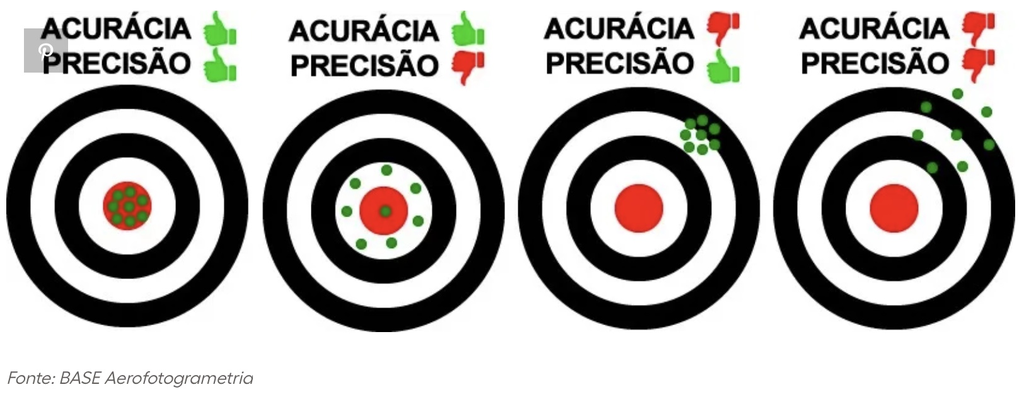

## Algumas Propriedades Assintóticas dos EMV

**Estimador Consistente**

Um estimador $\hat{\theta}_n$ é consistente para $\theta$ se, à medida que o tamanho da amostra $n$ aumenta, o estimador converge em probabilidade para o valor verdadeiro do parâmetro.

Matematicamente:

$$\hat{\theta}_n \xrightarrow{P} \theta \quad \text{quando} \quad n \to \infty$$

Ou, de forma equivalente, a variância do estimador converge a zero e o viés converge a zero conforme $n$ aumenta:

$$\lim_{n \to \infty} \text{Var}(\hat{\theta}_n) = 0 \quad \text{e} \quad \lim_{n \to \infty} \mathbb{E}(\hat{\theta}_n - \theta) = 0$$

## Propriedades dos Estimadores de Máxima Verossimilhança

Os estimadores obtidos pelo método da máxima verossimilhança possuem propriedades assintóticas desejáveis, assumindo que o modelo é correto:

- **Consistência Assintótica**

$\hat{\theta}$ converge em probabilidade para $\theta$ quando o tamanho da amostra aumenta.

$$\hat{\theta}_n \xrightarrow{p} \theta \quad \text{quando} \quad n \to \infty$$

- **Eficiência Assintótica**

$\hat{\theta}$ é assintoticamente o estimador com a menor variância possível.

- **Normalidade Assintótica**

A distribuição de $\hat{\theta}$ aproxima-se de distribuição unormal à medida que o tamanho da amostra aumenta.

$$\sqrt{n}(\hat{\theta}_n - \theta) \xrightarrow{d} N(0, I(\theta)^{-1})$$

## Propriedades dos EMV via Simulação de MC

```r
# fixando a média e o desvio-padrão de uma VA normal padronizada
mu <- 0
sigma <- 1

# n é tamanho de cada amostra.
# T é o número de simulacoes de cada amostra

n0 <- 10
n1 <- 100
n2 <- 1000
n3 <- 10000
T <- 1000

# fixa a semente do gerador de numeros aleatorios
set.seed(999)

# simula 1000 amostras (linhas) de tamanho 10 (colunas)
amostras0 <- rnorm(n0 * T, mu, sigma)
amostras0 <- matrix(amostras0, nrow = T, ncol = n0)
dim(amostras0)

# simula 1000 amostras de tamanho 100
amostras1 <- rnorm(n1 * T, mu, sigma)
amostras1 <- matrix(amostras1, nrow = T, ncol = n1)
dim(amostras1) # dim retorna n. de linhas x n. de colunas

# simula 1000 amostras de tamanho 1000
amostras2 <- rnorm(n2 * T, mu, sigma)
amostras2 <- matrix(amostras2, nrow = T, ncol = n2)
dim(amostras2)

# simula 1000 amostras de tamanho 10000
amostras3 <- rnorm(n3 * T, mu, sigma)
amostras3 <- matrix(amostras3, nrow = T, ncol = n3)
dim(amostras3)


## aqui, os EMV são:

# 1000 médias calculadas de 1000 amostras de tamanho 10
xbar0 <- apply(amostras0, 1, mean)

# 1000 médias calculadas de 1000 amostras de tamanho 100
xbar1 <- apply(amostras1, 1, mean)

# 1000 médias calculadas de 1000 amostras de tamanho 1000
xbar2 <- apply(amostras2, 1, mean)

# 1000 médias calculadas de 10000 amostras de tamanho 10000
xbar3 <- apply(amostras3, 1, mean)


## mostra a normalidade assintótica
hist(xbar0)
hist(xbar1)
hist(xbar2)
hist(xbar3)

## graficos quantil-quantil para testar a normalidade
qqnorm(xbar0)
qqnorm(xbar1)
qqnorm(xbar2)
qqnorm(xbar3)

# calcula o viés dos EMV
vies0 = xbar0 - mu
vies1 = xbar1 - mu
vies2 = xbar2 - mu
vies3 = xbar3 - mu

# viés médio
mean(vies0)
mean(vies1)
mean(vies2)
mean(vies3)
```

[output not shown]

## Exercício 1

**Verificação de Viés e Consistência de Estimadores**

Considere uma variável aleatória Y para a qual:

- $E[Y_i] = \mu$
- Os $Y_i$ são independentes.

Utilizando as propriedades do valor experado e do somatório de uma constante ($\sum_{i=1}^n c = nc$).

1. Verique se os seguintes estimadores de $\mu$ são não viesados.

$$a = \frac{1}{n} \sum_{i=1}^{n} Y_i + 1.5$$

$$b = \frac{1}{n} \sum_{i=1}^{n} Y_i + \sum_{i=1}^{5} \frac{Y_i}{n}$$

2. Pelos resultados do item a, você consegue avaliar se os estimadores são consistentes? Isto é, se cada estimador converge para $\mu$ à medida que $n \rightarrow \infty$

## Exercício 2

**EMV de $p$ em uma Distribuição Binomial**

Considere um experimento binomial com:

- Número de ensaios: $n$
- Probabilidade de sucesso: $\theta$
- Número de sucessos: $x$

A função de probabilidade da distribuição binomial é:

$$P(X = x) = \binom{n}{x} p^x (1 - p)^{n - x}$$

Sabemos que $n$ é conhecido, mas $p$ é **desconhecido**. Seu objetivo é encontrar uma **estimativa de Máxima Verossimilhança (EMV)** de $p$.

#### Dados

Suponha que, em 10 experimentos binomiais independentes com $n = 5$ tentativas cada, observamos os seguintes números de sucessos:

```r
dados <- c(3, 2, 4, 3, 2, 5, 1, 2, 3, 4)
```

## Referências

## Atualizando os Repositórios

**Instruções**

1. No terminal do RStudio, verifique quais arquivos/pastas foram modificados ou criados com:

```bash
git status
```

2. Você pode adicionar todos os arquivos de uma vez com:

```bash
git add .
```

3. Execute git status novamente para confirmar que todos os arquivos foram adicionados (aparecerão em verde sob “*Changes to be committed*”):

```bash
git status
```

4. Se tudo estiver em verde, faça um commit com uma mensagem descritiva:

```bash
git commit -m "atualizacoes aula 11"
```

5. Se algum arquivo ou pasta ainda aparecer em vermelho após o segundo git status, adicione as pastas/arquivos um por um:

```bash
git add relatorios/09-relatorio/09-relatorio.qmd
```

6. Execute git status novamente e faça o commit quando todos os arquivos estiverem em verde:

```bash
git commit -m "atualizacoes aula 11"
```

7. Envie o repositório local atualizado para o GitHub:

```bash
git push origin main
```